# Biomarathon Barcoding Data

Author

Libby Natola

Published

November 5, 2026

## Matt’s figures in R

I started by recreating Matt’s figures in the document this far.

### Samples per phylum

The first was the number of samples assigned to each phylum:

```r
phylum_hist <- sd %>%
  ggplot(aes(x = fct_infreq(Phylum))) +
  geom_histogram(stat = "count", fill = "#4472c4") +
  labs(x = "Phylum", y = "Total Samples")
# get that order
phylum_order <- sd$Phylum %>% fct_infreq() %>% levels()
sd <- sd %>%
  mutate(Phylum = factor(Phylum, levels = phylum_order))

ggsave("plots/biomarathon_barcoding_samples_per_phylum.png", plot = phylum_hist,
       height = 5, width = 8, units = "in", dpi = 400)

ggplotly(phylum_hist)
```

[interactive chart not shown]

### Novel bins

The second was the percent of BINs that were unique per phylum:

```r
phylum_pct_bar <- sd %>%
  group_by(Phylum, `BIN TYPE`) %>%
  mutate(`BIN TYPE` = case_when(`BIN TYPE` == "Unique" ~ "Novel BINs",
                                `BIN TYPE` == "Non-unique" ~ "Previously in BOLD",
                                TRUE ~ `BIN TYPE`),
         `BIN TYPE` = factor(`BIN TYPE`, levels = c("Previously in BOLD", "Novel BINs"))) %>%
  summarise(n = n_distinct(BIN), .groups = "drop") %>%
  filter(!is.na(`BIN TYPE`)) %>%
  ggplot(aes(x = Phylum, y = n, fill = `BIN TYPE`)) +
  geom_col(position = "fill") +
  scale_y_continuous(labels = percent, breaks = seq(0, 1, by = 0.1)) +
  scale_fill_manual(values = c(
    "Previously in BOLD" = novel_pal[2],
    "Novel BINs" = novel_pal[1])) +
  labs(x = "Phylum", y = "Percent of BINs", fill = NULL)

ggsave("plots/biomarathon_barcoding_pct_unique_per_phylum.png", plot = phylum_pct_bar,
       height = 5, width = 8, units = "in", dpi = 400)

ggplotly(phylum_pct_bar)
```

[interactive chart not shown]

```r
samples_pct_unique_phylum <- phylum_hist / phylum_pct_bar + plot_annotation(tag_levels = 'A')

ggsave("plots/biomarathon_barcoding_samples_and_pct_unique_per_phylum.png", plot = samples_pct_unique_phylum,
       height = 10, width = 7, units = "in", dpi = 400)
```

### Samples x novel BINS

Then I recreated the scatter plot where each point represents a phylum and the x-axis shows the number of samples assigned to that phylum and the y-axis shows the percent of BINs in that phylum that are novel.

```r
# get a row for each phylum, get number of samples in phylum, get number of novel bins in each phylum
sample_sums <- sd %>%
  group_by(Phylum) %>%
  summarise(num_samples = n())

samples_novel_bins_bar <- sd %>%
  group_by(Phylum, `BIN TYPE`) %>%
  summarise(novel_bins = n_distinct(BIN), groups = "drop") %>%
  pivot_wider(names_from = `BIN TYPE`, values_from = novel_bins, values_fill = 0) %>%
  select(-`NA`) %>%
  mutate(pct_uq = Unique/(`Non-unique`+Unique)) %>%
  select(-`Non-unique`, -Unique) %>%
  left_join(sample_sums, by = "Phylum") %>%
  ggplot(aes(x = num_samples, y = pct_uq)) +
  geom_point(color = "#4472c4") +
  labs(x = "Number of samples", y = "Novel BINs") +
  scale_y_continuous(labels = percent, breaks = seq(0, 1, by = 0.1))
```

```
`summarise()` has regrouped the output.
ℹ Summaries were computed grouped by Phylum and BIN TYPE.
ℹ Output is grouped by Phylum.
ℹ Use `summarise(.groups = "drop_last")` to silence this message.
ℹ Use `summarise(.by = c(Phylum, BIN TYPE))` for per-operation grouping
  (`?dplyr::dplyr_by`) instead.
```

```r
ggsave("plots/biomarathon_barcoding_novel_bins_per_sample.png", plot = samples_novel_bins_bar,
       height = 5, width = 8, units = "in", dpi = 400)
ggplotly(samples_novel_bins_bar)
```

[interactive chart not shown]

```r
samples_novel_bins_bar_phylumlabs <- sd %>%
  group_by(Phylum, `BIN TYPE`) %>%
  summarise(novel_bins = n_distinct(BIN), groups = "drop") %>%
  pivot_wider(names_from = `BIN TYPE`, values_from = novel_bins, values_fill = 0) %>%
  select(-`NA`) %>%
  mutate(pct_uq = Unique/(`Non-unique`+Unique)) %>%
  select(-`Non-unique`, -Unique) %>%
  left_join(sample_sums, by = "Phylum") %>%
  ggplot(aes(x = num_samples, y = pct_uq)) +
  geom_point(color = "#4472c4") +
  geom_text_repel(
    aes(label = Phylum),
    size = 3,
    max.overlaps = Inf,
    box.padding = 0.6,
    point.padding = 0.3,
    segment.color = "grey60"
  ) +
  labs(x = "Number of samples", y = "Percent novel BINs") +
  scale_y_continuous(labels = percent, breaks = seq(0, 1, by = 0.1))
```

```
`summarise()` has regrouped the output.
ℹ Summaries were computed grouped by Phylum and BIN TYPE.
ℹ Output is grouped by Phylum.
ℹ Use `summarise(.groups = "drop_last")` to silence this message.
ℹ Use `summarise(.by = c(Phylum, BIN TYPE))` for per-operation grouping
  (`?dplyr::dplyr_by`) instead.
```

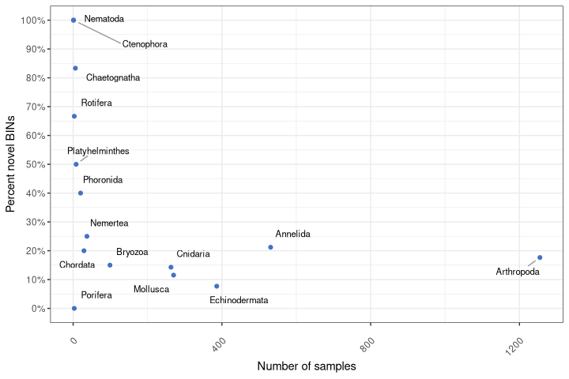

```r
samples_novel_bins_bar_phylumlabs
```

```r
ggsave("plots/biomarathon_barcoding_novel_bins_per_sample_phylumlabs.png",
       plot = samples_novel_bins_bar_phylumlabs,
       height = 5, width = 8, units = "in", dpi = 400)
```

### BIN accumulation curve

Finally, I recreated the BIN accumulation curve. I’m not sure exactly how Matt made this so I used the specaccum function on a sample x BIN matrix from vegan and came up with something similar to Matt’s.

```r
# build a sample x BIN incidence matrix
bin_matrix <- sd %>%
  filter(!is.na(BIN)) %>%
  distinct(`Sample ID...1`, BIN) %>%
  mutate(present = 1) %>%
  pivot_wider(names_from = BIN, values_from = present, values_fill = 0) %>%
  column_to_rownames("Sample ID...1")

set.seed(123)
bin_accum <- specaccum(bin_matrix, method = "random", permutations = 999)

accum_df <- data.frame(
  samples = bin_accum$sites,
  bins = bin_accum$richness
)

bin_accumulation_curve <- ggplot(accum_df, aes(x = samples, y = bins)) +
  geom_line(color = "#4472c4", linewidth = 1) +
  labs(x = "Number of samples", y = "Cumulative count of BINs") +
  theme_classic()

ggsave("plots/biomarathon_barcoding_bin_accumulation_curve.png", plot = bin_accumulation_curve,
       height = 5, width = 8, units = "in", dpi = 400)

ggplotly(bin_accumulation_curve)
```

[interactive chart not shown]

```r
novel_bins_and_accumulation <- samples_novel_bins_bar / bin_accumulation_curve + plot_annotation(tag_levels = 'A', )

ggsave("plots/biomarathon_barcoding_novel_per_sample+accumulation_curve.png", plot = novel_bins_and_accumulation,
       height = 10, width = 7, units = "in", dpi = 400)
novel_bins_and_accumulation_phylumlabs <- samples_novel_bins_bar_phylumlabs / bin_accumulation_curve + plot_annotation(tag_levels = 'A', )

ggsave("plots/biomarathon_barcoding_novel_per_sample_phylumlabs+accumulation_curve.png", plot = novel_bins_and_accumulation_phylumlabs,
       height = 10, width = 7, units = "in", dpi = 400)
```

## New figures

After recreating what Matt made I plotted some new figures to identify any patterns in what BINs are novel.

### Time

First we wanted to compare novel vs non-novel bins by month to see if there are times of year when we get more novel taxa than others.

```r
num_novel_month <- sd %>%
  rename(CollectionDate = `Collection Date...29`) %>%
  mutate(CollectionDate = as.Date(CollectionDate, format = "%d-%b-%Y"),
         month = as.numeric(format(CollectionDate, "%m")),
         month_text = month(month, label = TRUE, abbr = TRUE),
         year = as.numeric(format(CollectionDate, "%Y"))) %>%
  group_by(`BIN TYPE`, month, month_text, year) %>%
  summarise(n = n_distinct(BIN), .groups = "drop") %>%
  filter(!is.na(`BIN TYPE`) & !is.na(month) & !is.na(year)) %>%
  ggplot(aes(x = month_text, y = n, fill = `BIN TYPE`)) +
  geom_col(position = "dodge") +
  facet_wrap(~ year, ncol = 1) +
  scale_fill_manual(values = novel_pal) +
  labs(x = "Month", y = "Number of BINs", fill = NULL)+
  theme(panel.spacing.y = unit(0.2, "lines"))

ggsave("plots/biomarathon_barcoding_novel_per_month.png", plot = num_novel_month,
       height = 10, width = 8, units = "in", dpi = 400)

ggplotly(num_novel_month)
```

[interactive chart not shown]

```r
pct_novel_month_years <- sd %>%
  rename(CollectionDate = `Collection Date...29`) %>%
  mutate(CollectionDate = as.Date(CollectionDate, format = "%d-%b-%Y"),
         month = as.numeric(format(CollectionDate, "%m")),
         month_text = month(month, label = TRUE, abbr = TRUE),
         year = as.numeric(format(CollectionDate, "%Y")),
         `BIN TYPE` = case_when(`BIN TYPE` == "Unique" ~ "Novel BINs",
                                `BIN TYPE` == "Non-unique" ~ "Previously in BOLD",
                                TRUE ~ `BIN TYPE`),
         `BIN TYPE` = factor(`BIN TYPE`, levels = c("Previously in BOLD", "Novel BINs"))) %>%
  filter(!is.na(`BIN TYPE`) & !is.na(month) & !is.na(year)) %>%
  group_by(`BIN TYPE`, month, month_text, year) %>%
  summarise(n = n_distinct(BIN), .groups = "drop") %>%
  #pivot_wider(names_from = `BIN TYPE`, values_from = n, values_fill = 0) %>%
  ggplot(aes(x = month_text, y = n, fill = `BIN TYPE`)) +
  geom_col(position = "fill") +
  facet_wrap(~ year, ncol = 1) +
  scale_fill_manual(values = c(
    "Previously in BOLD" = novel_pal[2],
    "Novel BINs" = novel_pal[1])) +
  labs(x = "Month", y = "Number of BINs", fill = NULL)+
  theme(panel.spacing.y = unit(0.2, "lines"))

ggsave("plots/biomarathon_barcoding_pct_novel_per_month_years_sep.png", plot = pct_novel_month_years,
       height = 10, width = 8, units = "in", dpi = 400)

ggplotly(pct_novel_month_years)
```

[interactive chart not shown]

```r
# convert to wide format
sd_wide <- sd %>%
    rename(CollectionDate = `Collection Date...29`) %>%
    mutate(CollectionDate = as.Date(CollectionDate, format = "%d-%b-%Y"),
           month = as.numeric(format(CollectionDate, "%m")),
           year  = as.numeric(format(CollectionDate, "%Y"))) %>%
    group_by(`BIN TYPE`, month, year) %>%
    summarise(n = n_distinct(BIN), .groups = "drop") %>%
    filter(!is.na(`BIN TYPE`) & !is.na(month) & !is.na(year)) %>%
    pivot_wider(names_from = `BIN TYPE`, values_from = n, values_fill = 0) %>%
    mutate(total = Unique + `Non-unique`)

m1 <- glmer(cbind(Unique, total - Unique) ~ factor(month) + (1 | year),
            data = sd_wide, family = binomial)
```

```
boundary (singular) fit: see help('isSingular')
```

```r
m1
```

```
Generalized linear mixed model fit by maximum likelihood (Laplace
  Approximation) [glmerMod]
 Family: binomial  ( logit )
Formula: cbind(Unique, total - Unique) ~ factor(month) + (1 | year)
   Data: sd_wide
      AIC       BIC    logLik -2*log(L)  df.resid
 126.8334  144.7915  -51.4167  102.8334        21
Random effects:
 Groups Name        Std.Dev.
 year   (Intercept) 0
Number of obs: 33, groups:  year, 4
Fixed Effects:
    (Intercept)   factor(month)2   factor(month)3   factor(month)4
       -2.12823          0.18232         -0.59306         -0.03327
 factor(month)5   factor(month)6   factor(month)7   factor(month)8
       -0.62634         -0.24667          0.06278          0.68975
 factor(month)9  factor(month)10  factor(month)11
        0.26748          0.37037         -0.14904
optimizer (Nelder_Mead) convergence code: 0 (OK) ; 0 optimizer warnings; 1 lme4 warnings
```

```r
m2 <- glmmTMB(cbind(Unique, total - Unique) ~ factor(month) + (1 | year),
              data = sd_wide, family = betabinomial)
m2
```

```
Formula:          cbind(Unique, total - Unique) ~ factor(month) + (1 | year)
Data: sd_wide
      AIC       BIC    logLik -2*log(L)  df.resid
       NA        NA        NA        NA        20
Random-effects (co)variances:

Conditional model:
 Groups Name        Std.Dev.
 year   (Intercept) 0.0001914

Number of obs: 33 / Conditional model: year, 4

Dispersion parameter for betabinomial family (): 6.11e+07

Fixed Effects:

Conditional model:
    (Intercept)   factor(month)2   factor(month)3   factor(month)4
       -2.12804          0.18210         -0.59329         -0.03346
 factor(month)5   factor(month)6   factor(month)7   factor(month)8
       -0.62653         -0.24686          0.06259          0.68956
 factor(month)9  factor(month)10  factor(month)11
        0.26729          0.37018         -0.14926
```

```r
m0 <- glm(cbind(Unique, total - Unique) ~ factor(month), data = sd_wide, family = binomial)
m0
```

```
Call:  glm(formula = cbind(Unique, total - Unique) ~ factor(month),
    family = binomial, data = sd_wide)

Coefficients:
    (Intercept)   factor(month)2   factor(month)3   factor(month)4
       -2.12823          0.18232         -0.59306         -0.03327
 factor(month)5   factor(month)6   factor(month)7   factor(month)8
       -0.62634         -0.24667          0.06278          0.68975
 factor(month)9  factor(month)10  factor(month)11
        0.26748          0.37037         -0.14904

Degrees of Freedom: 32 Total (i.e. Null);  22 Residual
Null Deviance:      30.03
Residual Deviance: 18.51    AIC: 124.8
```

```r
anova(m0)   # or AIC(m0, m1, m2) — expect m0 to fit essentially as well, with fewer params
```

|  | Df | Deviance | Resid. Df | Resid. Dev | Pr(>Chi) |
| --- | --- | --- | --- | --- | --- |
| NULL | NA | NA | 32 | 30.03073 | NA |
| factor(month) | 10 | 11.52313 | 22 | 18.50760 | 0.3182382 |

```r
m_null <- glm(cbind(Unique, total - Unique) ~ 1, data = sd_wide, family = binomial)
m_null
```

```
Call:  glm(formula = cbind(Unique, total - Unique) ~ 1, family = binomial,
    data = sd_wide)

Coefficients:
(Intercept)
     -2.164

Degrees of Freedom: 32 Total (i.e. Null);  32 Residual
Null Deviance:      30.03
Residual Deviance: 30.03    AIC: 116.4
```

```r
anova(m_null, m0, test = "Chisq")
```

|  | Resid. Df | Resid. Dev | Df | Deviance | Pr(>Chi) |
| --- | --- | --- | --- | --- | --- |
| 1 | 32 | 30.03073 | NA | NA | NA |
| 2 | 22 | 18.50760 | 10 | 11.52313 | 0.3182382 |

I tested the relationship between month and BIN novelty with a few statistical tests. I started with GLMM because there was a lot of variation in number of samples sequenced across months and years, because we are really interested in the proportions of novel BINs per month rather than the counts, and because the same months were sampled repeatedly across multiple years, I wanted to try a year-level random effect. I ran it both with and without the beta binomial family and checked these for overdispersion. They both showed the random effect was 0 so year doesn’t affect these models and we don’t need to include it. The beta binomial GLMM had a very high dispersion parameter, indicating negligible extra-binomial variance (it effectively converges to a standard binomial) so the beta-binomial fit wasn’t needed either. Therefore, I decided to just run a regular GLM, which had a lower AIC (124.8) than the binomial GLMM (126.8) (beta-binomial GLMM was unable to converge and has AIC of NA). I ran an ANOVA of the GLM comparing this model to an intercept-only null model which was non-significant (χ² = 11.52, df = 10, p = 0.32), giving no evidence of a monthly effect on BIN novelty p-value was 0.32 so no pattern by month. I also ran a null model to compare against the GLM and found the null model had a lower AIC (116.4), confirming there’s no pattern associated with month.

```r
pct_novel_month <- sd %>%
  rename(CollectionDate = `Collection Date...29`) %>%
  mutate(CollectionDate = as.Date(CollectionDate, format = "%d-%b-%Y"),
         month = format(CollectionDate, "%m")) %>%
  group_by(`BIN TYPE`, month) %>%
  summarise(n = n_distinct(BIN), .groups = "drop") %>%
  filter(!is.na(`BIN TYPE`) & !is.na(month)) %>%
  ggplot(aes(x = month, y = n, fill = `BIN TYPE`)) +
  geom_col(position = "fill") +
  scale_y_continuous(labels = percent, breaks = seq(0, 1, by = 0.1)) +
  scale_fill_manual(values = novel_pal) +
  labs(x = "Month", y = "Percent of BINs", fill = NULL)

ggsave("plots/biomarathon_barcoding_pct_novel_per_month.png", plot = pct_novel_month,
       height = 5, width = 8, units = "in", dpi = 400)

ggplotly(pct_novel_month)
```

[interactive chart not shown]

It looks like maybe there are more BINs detected in April overall, we have highest non-unique and unique BINs in April 2021-2023. Percentage-wise I’m not seeing much of a pattern.

We were also interested in looking at this question by season.

```r
num_novel_season <- sd %>%
  rename(CollectionDate = `Collection Date...29`) %>%
  mutate(CollectionDate = as.Date(CollectionDate, format = "%d-%b-%Y"),
         season = str_to_title(time2season(CollectionDate, out.fmt = "seasons"))) %>%
  filter(!is.na(season)) %>%
  group_by(`BIN TYPE`, season) %>%
  summarise(season_sum = n_distinct(BIN)) %>%
  filter(!is.na(`BIN TYPE`)) %>%
  ggplot(aes(x = season, y = season_sum, fill = `BIN TYPE`)) +
  geom_bar(stat = "identity") +
  facet_wrap(~`BIN TYPE`, ncol = 1) +
  scale_fill_manual(values = novel_pal) +
  labs(x = "Season", y = "Number of BINs", fill = NULL) +
  theme(panel.spacing.y = unit(0.2, "lines"))
```

```
`summarise()` has regrouped the output.
ℹ Summaries were computed grouped by BIN TYPE and season.
ℹ Output is grouped by BIN TYPE.
ℹ Use `summarise(.groups = "drop_last")` to silence this message.
ℹ Use `summarise(.by = c(BIN TYPE, season))` for per-operation grouping
  (`?dplyr::dplyr_by`) instead.
```

```r
ggsave("plots/biomarathon_barcoding_novel_per_season.png", plot = num_novel_season,
       height = 7, width = 8, units = "in", dpi = 400)

ggplotly(num_novel_season)
```

[interactive chart not shown]

```r
pct_novel_season <- sd %>%
  rename(CollectionDate = `Collection Date...29`) %>%
  mutate(CollectionDate = as.Date(CollectionDate, format = "%d-%b-%Y"),
         season = str_to_title(time2season(CollectionDate, out.fmt = "seasons"))) %>%
  filter(!is.na(season)) %>%
  group_by(`BIN TYPE`, season) %>%
  summarise(season_sum = n_distinct(BIN)) %>%
  filter(!is.na(`BIN TYPE`)) %>%
  ggplot(aes(x = season, y = season_sum, fill = `BIN TYPE`)) +
  geom_col(position = "fill") +
  scale_y_continuous(labels = percent, breaks = seq(0, 1, by = 0.1)) +
  scale_fill_manual(values = novel_pal) +
  labs(x = "Year-month", y = "Percent of BINs", fill = NULL)
```

```
`summarise()` has regrouped the output.
ℹ Summaries were computed grouped by BIN TYPE and season.
ℹ Output is grouped by BIN TYPE.
ℹ Use `summarise(.groups = "drop_last")` to silence this message.
ℹ Use `summarise(.by = c(BIN TYPE, season))` for per-operation grouping
  (`?dplyr::dplyr_by`) instead.
```

```r
ggsave("plots/biomarathon_barcoding_pct_novel_per_season.png", plot = pct_novel_season,
       height = 5, width = 8, units = "in", dpi = 400)

ggplotly(pct_novel_season)
```

[interactive chart not shown]

I’m still not seeing any temporal patterns here as to when we detect novel BINs, but I ran some statistical tests on this to double check.

```r
 sd_seas_wide <- sd %>%
  rename(CollectionDate = `Collection Date...29`) %>%
  mutate(CollectionDate = as.Date(CollectionDate, format = "%d-%b-%Y"),
         season = time2season(CollectionDate, out.fmt = "seasons")) %>%
  filter(!is.na(season)) %>%
  group_by(`BIN TYPE`, season) %>%
  summarise(season_sum = n_distinct(BIN)) %>%
  filter(!is.na(`BIN TYPE`)) %>%
  pivot_wider(names_from = `BIN TYPE`, values_from = season_sum, values_fill = 0) %>%
  mutate(total = Unique + `Non-unique`)
```

```
`summarise()` has regrouped the output.
ℹ Summaries were computed grouped by BIN TYPE and season.
ℹ Output is grouped by BIN TYPE.
ℹ Use `summarise(.groups = "drop_last")` to silence this message.
ℹ Use `summarise(.by = c(BIN TYPE, season))` for per-operation grouping
  (`?dplyr::dplyr_by`) instead.
```

```r
m_season <- glm(cbind(Unique, total - Unique) ~ season, data = sd_seas_wide, family = binomial)
m_season
```

```
Call:  glm(formula = cbind(Unique, total - Unique) ~ season, family = binomial,
    data = sd_seas_wide)

Coefficients:
 (Intercept)  seasonspring  seasonsummer  seasonwinter
    -1.75786      -0.14638       0.10127      -0.08797

Degrees of Freedom: 3 Total (i.e. Null);  0 Residual
Null Deviance:      0.9287
Residual Deviance: -4.663e-15   AIC: 26.78
```

```r
anova(m_season)
```

|  | Df | Deviance | Resid. Df | Resid. Dev | Pr(>Chi) |
| --- | --- | --- | --- | --- | --- |
| NULL | NA | NA | 3 | 9.286867e-01 | NA |
| season | 3 | 0.9286867 | 0 | -4.662937e-15 | 0.8185001 |

After running a GLM on season instead of month, I found the data don’t support a seasonal pattern of novel bin detection (χ² = 0.93, df = 3, p = 0.82).

### Depth

Next we wanted to compare novel vs non-novel bins by sampling depth.

```r
num_novel_depth <- sd %>%
  rename(Depth = `Depth...11`,) %>%
  mutate(Depth = as.numeric(Depth),
         Depth_bin = cut(Depth,
                          breaks = seq(0, ceiling(max(Depth, na.rm = TRUE) / 50) * 50, by = 50),
                          include.lowest = TRUE),
         Depth_bin_display = str_remove_all(Depth_bin, "[\\(\\)\\[\\]]"),
         Depth_bin_display = str_replace(Depth_bin_display, "," , "-"),
         Depth_bin_display = factor(Depth_bin_display,
                                    levels = c("0-50", "50-100", "100-150", "150-200", "200-250", "250-300"),
                                    labels = c("0-50", "51-100", "101-150", "151-200", "201-250", "251-300"))) %>%
  filter(!is.na(Depth_bin)) %>%
  group_by(`BIN TYPE`, Depth_bin, Depth_bin_display) %>%
  summarise(n = n_distinct(BIN), .groups = "drop") %>%
  filter(!is.na(`BIN TYPE`)) %>%
  ggplot(aes(x = Depth_bin_display, y = n, fill = `BIN TYPE`)) +
  geom_col() +
  facet_wrap(~`BIN TYPE`, ncol = 1, scales = "free_y") +
  scale_fill_manual(values = novel_pal) +
  labs(x = "Depth (m)", y = "Number of BINs", fill = NULL) +
  theme(panel.spacing.y = unit(0.2, "lines"))

ggplotly(num_novel_depth)
```

[interactive chart not shown]

```r
ggsave("plots/biomarathon_barcoding_novel_per_depth.png", plot = num_novel_depth,
       height = 7, width = 8, units = "in", dpi = 400)

pct_novel_depth <- sd %>%
  rename(Depth = `Depth...11`,) %>%
  mutate(Depth = as.numeric(Depth),
         Depth_bin = cut(Depth,
                          breaks = seq(0, ceiling(max(Depth, na.rm = TRUE) / 50) * 50, by = 50),
                          include.lowest = TRUE),
         Depth_bin_display = str_remove_all(Depth_bin, "[\\(\\)\\[\\]]"),
         Depth_bin_display = str_replace(Depth_bin_display, "," , "-"),
         Depth_bin_display = factor(Depth_bin_display,
                                    levels = c("0-50", "50-100", "100-150", "150-200", "200-250", "250-300"),
                                    labels = c("0-50", "51-100", "101-150", "151-200", "201-250", "251-300"))) %>%
  filter(!is.na(Depth_bin)) %>%
  group_by(`BIN TYPE`, Depth_bin, Depth_bin_display) %>%
  summarise(n = n_distinct(BIN), .groups = "drop") %>%
  filter(!is.na(`BIN TYPE`)) %>%
  ggplot(aes(x = Depth_bin_display, y = n, fill = `BIN TYPE`)) +
  geom_col(position = "fill") +
  scale_y_continuous(labels = percent, breaks = seq(0, 1, by = 0.1)) +
  scale_fill_manual(values = novel_pal) +
  labs(x = "Depth (m)", y = "Percent of BINs", fill = NULL)

ggplotly(pct_novel_depth)
```

[interactive chart not shown]

```r
ggsave("plots/biomarathon_barcoding_pct_novel_per_depth.png", plot = pct_novel_depth,
       height = 5, width = 8, units = "in", dpi = 400)


table(as.numeric(sd$Depth...11))
```

```
  0 0.5   1   2   3   4   5 5.5   6   7   8   9  11  97  98 100 120 135 150 193
 28 162 621  32  31  61 141  11 256 462  82  98   6   5  20   4   2  14  11 159
200 210 220 230 234 240 250 260 265 270
 42   8   7   7   3   7  16 153   1   2
```

Most BINs were shallow, not a big difference in novel/known BINs across depths. I’m noticing the depths are pretty discontinuous, do we want to present the depths as less continuous in the plot (eg, instead of 50m bins, one for 0-11, another for 97-150, a third for 193-270)?

As a first pass I tested the relationship between sampling depth and BIN novelty with a Man-Whitney U test because the depth data are continuous, but aren’t normally distributed. I also ran an logistic regression because it can provide more detailed information on the response of BIN novelty to depth and it uses the actual depth values, not just the ranks, which might be important with these discontinuous samplings.

```r
sd_mwu <- sd %>%
  rename(Depth = `Depth...11`,) %>%
  filter(!is.na(Depth) & !is.na(`BIN TYPE`)) %>%
  mutate(Depth = as.numeric(Depth),
         BinType = factor(`BIN TYPE`)) %>%
  wilcox.test(Depth ~ BinType, data = .)

sd_mwu
```

```
    Wilcoxon rank sum test with continuity correction

data:  Depth by BinType
W = 135796, p-value = 0.9895
alternative hypothesis: true location shift is not equal to 0
```

```r
sd_glm <- sd %>%
  rename(Depth = `Depth...11`) %>%
  filter(!is.na(Depth) & !is.na(`BIN TYPE`)) %>%
  mutate(Depth = as.numeric(Depth),
         BinType = factor(`BIN TYPE`))  # binomial() will use the 2nd level as "success"

m_depth <- glm(BinType ~ Depth, family = binomial, data = sd_glm)
summary(m_depth)
```

```
Call:
glm(formula = BinType ~ Depth, family = binomial, data = sd_glm)

Coefficients:
              Estimate Std. Error z value Pr(>|z|)
(Intercept) -3.0135335  0.1081229 -27.871   <2e-16 ***
Depth        0.0009381  0.0010628   0.883    0.377
---
Signif. codes:  0 '***' 0.001 '**' 0.01 '*' 0.05 '.' 0.1 ' ' 1

(Dispersion parameter for binomial family taken to be 1)

    Null deviance: 942.87  on 2417  degrees of freedom
Residual deviance: 942.12  on 2416  degrees of freedom
AIC: 946.12

Number of Fisher Scoring iterations: 5
```

Neither Mann-Whitney U test (p = 0.99) nor the logistic regression (p = 0.38) detected significant associations between bin novelty and depth of sample collection.

### Holoplankton vs meroplankton

Finally we wanted to compare novel vs non-novel bins by holo/meroplankton.

```r
num_holo_mero <- sd %>%
  group_by(`BIN TYPE`, holo_mero) %>%
  summarise(n = n_distinct(BIN), .groups = "drop") %>%
  filter(!is.na(`BIN TYPE`)) %>%
  ggplot(aes(x = holo_mero, y = n, fill = `BIN TYPE`)) +
  geom_col() +
  facet_wrap(~`BIN TYPE`, ncol = 1, scales = "free_y") +
  scale_fill_manual(values = novel_pal) +
  labs(x = "Holo-vs-meroplankton", y = "Number of BINs", fill = NULL) +
  theme(panel.spacing.y = unit(0.2, "lines"))

ggsave("plots/biomarathon_barcoding_novel_per_holomero.png", plot = num_holo_mero,
       height = 7, width = 8, units = "in", dpi = 400)

ggplotly(num_holo_mero)
```

[interactive chart not shown]

```r
pct_holo_mero <- sd %>%
  group_by(`BIN TYPE`, holo_mero) %>%
  summarise(n = n_distinct(BIN), .groups = "drop") %>%
  filter(!is.na(`BIN TYPE`)) %>%
  ggplot(aes(x = holo_mero, y = n, fill = `BIN TYPE`)) +
  geom_col(position = "fill") +
  scale_y_continuous(labels = percent, breaks = seq(0, 1, by = 0.1)) +
  scale_fill_manual(values = novel_pal) +
  labs(x = "Holo-vs-meroplankton", y = "Percent of BINs", fill = NULL)

ggsave("plots/biomarathon_barcoding_pct_novel_per_holomero.png", plot = pct_holo_mero,
       height = 5, width = 8, units = "in", dpi = 400)

ggplotly(pct_holo_mero)
```

[interactive chart not shown]

```r
sd %>% select(`Field ID`, `Process ID`, Phylum, BIN, `BIN TYPE`, Identification, Class, Order, Family, Subfamily, Tribe, Genus, Species, Identification_and_rank, holo_mero) %>% filter(is.na(holo_mero))
```

[output not shown]

[output cut: 1761 more lines]

I joined the BINs to the holo-mero list based on the species identification. For these, any taxon marked “neither” was in the holo-mero list, and that list marked the taxon as neither holo nor mero plankton. Anything marked NA here was not included in the list. Maybe it is worth revisiting the NAs and seeing if we can manually assign any of those? I did add the ranks for the join so any higher level taxa should be formatted the same as the mapping sheet I’m using.

Using just the samples we do have info on, I ran a fisher’s test to see if there are more novel bins for taxa that have non-planktonic life phases.

```r
sd %>%
  group_by(`BIN TYPE`, holo_mero) %>%
  summarise(n = n_distinct(BIN), .groups = "drop") %>%
  filter(!is.na(`BIN TYPE`), holo_mero != "neither") %>%
  pivot_wider(names_from = holo_mero, values_from = n) %>%
  column_to_rownames("BIN TYPE") %>%
  as.matrix() %>%
  fisher.test()
```

```
    Fisher's Exact Test for Count Data

data:  .
p-value = 0.3878
alternative hypothesis: true odds ratio is not equal to 1
95 percent confidence interval:
 0.09472009 3.24217390
sample estimates:
odds ratio
 0.4869228
```

We didn’t detect any differences between holo and mero plankton, but note that we only had 3 unique holoplankton and 6 unique meroplankton.